# Data analysis and visulization using R

### *What you can learn from this tutorial?*

#### R basics

- Understanding the strength and weakness of R.
- Install R and RStudio. Manage packages.
- data types, functions.
- Working with data frame.

#### Make Tables and Plots

- Use R to summarize data.
- Plotting your data.
- Fine tuning your plots.

#### Data analysis

- Work with continuous data.
- Linear regression.
- Work with categorical data.
- Logistic regression.
- Time-to-event data and survival analysis.

#### Bioinformatics

- `ape` package for reading and analyze sequence data
- `ggtree` (and supplemental packages) to plot beautiful phylogenetic trees.

#### Extras

- Work with missing data.
- Export your data.
- Version control.

### *Why is special about this tutorial?*

- Using biomedical data and cases as examples
- Use the latest packages and features
- A great reference book. [R for Health Data Science](https://argoshare.is.ed.ac.uk/healthyr_book/)

[figure not shown]

### *Examples*

#### 1. Summarizing data and make tables using a simple package

Load required libraries

```r
library(dplyr)
library(tidyverse)
library(table1)
library(knitr)
library(arsenal)
library(ggplot2)
library(patchwork)
library(tidyr)
```

Read the data from a .csv file as a data frame.

```r
dfall <- read.csv("./data/data.csv", header = TRUE)
```

Quick examine the data. Look at the first 4 records.

```r
dfall %>% head(4)
```

|  | id | ngscollectdate | hivdxyr | gender | racecat | risk2 | owning_jd_region_fsu | age_cat30 | acute | incluster | dx_ngs_cat | Process.Date | Decision | Decision.Date | Download | TCS_PR | TCS_RT | TCS_IN | TCS_V1V3 | PI_RT | PI_V1V3 | DIST20_RT | DIST20_V1V3 | Recency | SDRM_PR | SDRM_RT | SDRM_IN | Pool..Lib.ID..Index | ngscollectyr | … |
| --- | --- | --- | --- | --- | --- | --- | --- | --- | --- | --- | --- | --- | --- | --- | --- | --- | --- | --- | --- | --- | --- | --- | --- | --- | --- | --- | --- | --- | --- | --- |
| 1 | 1 | 12/28/17 | 2017 | Male | Black | MSM | Charlotte | No | 0 | Yes | <30 days | 8/15/18 | Success | 8/11/18 | NA | 205 | 76 | 181 | 142 | 0.0393 | 0.0077 | 0.0000 | 0.0000 | possible dual |  |  | E138D:24.31(18.25-31.23); | PD001, PD001-1, 1, 1 | 2018 | … |
| 2 | 2 | 12/31/18 | 2018 | Male | Black | MSM | Greensboro | Yes | 0 | No | <30 days | 2/5/19 | Success | 2/5/19 | NA | 16 | 40 | 72 | 0 | 0.0019 | 0.0000 | 0.0000 | 0.0000 | RT only recent |  |  |  | PD033, PD033-11, 11, 1 | 2018 | … |
| 3 | 3 | 12/31/18 | 2018 | Male | Black | MSM | Winterville | Yes | 0 | No | <30 days | 2/5/19 | Success | 2/5/19 | NA | 731 | 1295 | 1317 | 269 | 0.0477 | 0.0213 | 0.0038 | 0.0022 | chronic |  |  |  | PD033, PD033-13, 13, 1 | 2018 | … |
| 4 | 4 | 1/3/18 | 2017 | Female | Hispanic | HET-F | Raleigh | No | 0 | No | <30 days | 8/15/18 | Success | 8/16/18 | NA | 378 | 312 | 500 | 200 | 0.0125 | 0.0300 | 0.0076 | 0.0052 | chronic |  |  |  | PD001, PD001-4, 4, 1 | 2018 | … |

add labels, relevel some factors

```r
dfall <- dfall %>%
  mutate_at(c("TCS_PR","TCS_RT","TCS_IN", "TCS_V1V3", "PI_RT","PI_V1V3","DIST20_RT", "DIST20_V1V3"), funs(as.numeric)) %>%
  mutate(
  racecat = factor(racecat, levels = c("White", "Black", "Hispanic", "Other/Unkn")),
  risk2 = factor(risk2, levels = c("MSM", "HET-F", "HET-M", 'PWID-F', 'PWID-M', 'OTHER/UNKN'))
  )

labels(dfall) <- c(ngscollectyr = 'Year of Diagnosis',
                   gender = 'Gender',
                   racecat = 'Race',
                   age_cat30 = 'Age ≤ 30y/o',
                   risk2 = 'Risk factor',
                   recent_cat = 'Recency Category',
                   owning_jd_region_fsu = 'Region in NC',
                   incluster = 'In Clusters',
                   cd4_value = 'CD4 count (cells/µL)',
                   vl_log_value = 'Viral Load (Log10 copies/mL)'
)
```

Summarize the data

Table 1. Characteristics of sequenced participants with new diagnoses in NC from 2018-2021.

```r
dfall %>%
tableby(ngscollectyr ~ recent_cat + gender + racecat + age_cat30 + risk2 + owning_jd_region_fsu + incluster + cd4_value + vl_log_value,
       data = .,cat.simplify=F, numeric.stats= c("median","q1q3"), test=T) %>%
 summary(.,digits=1, digits.count=0, digits.pct=1, digits.p=2, title=NULL)
```

|  | 2018 (N=270) | 2019 (N=237) | 2020 (N=112) | 2021 (N=195) | Total (N=814) | p value |
| --- | --- | --- | --- | --- | --- | --- |
| **Recency Category** |  |  |  |  |  | 0.02 |
| Chronic | 131 (48.5%) | 109 (46.0%) | 43 (38.4%) | 97 (49.7%) | 380 (46.7%) |  |
| Indeterminant | 44 (16.3%) | 21 (8.9%) | 16 (14.3%) | 31 (15.9%) | 112 (13.8%) |  |
| Recent | 95 (35.2%) | 107 (45.1%) | 53 (47.3%) | 67 (34.4%) | 322 (39.6%) |  |
| **Gender** |  |  |  |  |  | 0.08 |
| Female | 44 (16.3%) | 29 (12.2%) | 7 (6.2%) | 29 (14.9%) | 109 (13.4%) |  |
| Male | 222 (82.2%) | 202 (85.2%) | 100 (89.3%) | 163 (83.6%) | 687 (84.4%) |  |
| Transgender Female | 4 (1.5%) | 6 (2.5%) | 4 (3.6%) | 3 (1.5%) | 17 (2.1%) |  |
| Transgender Male | 0 (0.0%) | 0 (0.0%) | 1 (0.9%) | 0 (0.0%) | 1 (0.1%) |  |
| **Race** |  |  |  |  |  | 0.04 |
| White | 46 (17.0%) | 38 (16.0%) | 26 (23.2%) | 29 (14.9%) | 139 (17.1%) |  |
| Black | 191 (70.7%) | 147 (62.0%) | 70 (62.5%) | 126 (64.6%) | 534 (65.6%) |  |
| Hispanic | 26 (9.6%) | 30 (12.7%) | 10 (8.9%) | 28 (14.4%) | 94 (11.5%) |  |
| Other/Unkn | 7 (2.6%) | 22 (9.3%) | 6 (5.4%) | 12 (6.2%) | 47 (5.8%) |  |
| **Age ≤ 30y/o** |  |  |  |  |  | < 0.01 |
| No | 109 (40.4%) | 76 (32.1%) | 33 (29.5%) | 90 (46.2%) | 308 (37.8%) |  |
| Yes | 161 (59.6%) | 161 (67.9%) | 79 (70.5%) | 105 (53.8%) | 506 (62.2%) |  |
| **Risk factor** |  |  |  |  |  | < 0.01 |
| MSM | 183 (67.8%) | 169 (71.3%) | 82 (73.2%) | 127 (65.1%) | 561 (68.9%) |  |
| HET-F | 39 (14.4%) | 25 (10.5%) | 5 (4.5%) | 6 (3.1%) | 75 (9.2%) |  |
| HET-M | 38 (14.1%) | 28 (11.8%) | 6 (5.4%) | 9 (4.6%) | 81 (10.0%) |  |
| PWID-F | 5 (1.9%) | 0 (0.0%) | 0 (0.0%) | 1 (0.5%) | 6 (0.7%) |  |
| PWID-M | 5 (1.9%) | 9 (3.8%) | 8 (7.1%) | 5 (2.6%) | 27 (3.3%) |  |
| OTHER/UNKN | 0 (0.0%) | 6 (2.5%) | 11 (9.8%) | 47 (24.1%) | 64 (7.9%) |  |
| **Region in NC** |  |  |  |  |  | < 0.01 |
| Asheville | 21 (7.8%) | 22 (9.3%) | 8 (7.1%) | 12 (6.2%) | 63 (7.7%) |  |
| Charlotte | 48 (17.8%) | 12 (5.1%) | 5 (4.5%) | 11 (5.6%) | 76 (9.3%) |  |
| Fayetteville | 26 (9.6%) | 32 (13.5%) | 17 (15.2%) | 19 (9.7%) | 94 (11.5%) |  |
| Greensboro | 66 (24.4%) | 70 (29.5%) | 30 (26.8%) | 46 (23.6%) | 212 (26.0%) |  |
| Raleigh | 54 (20.0%) | 57 (24.1%) | 19 (17.0%) | 52 (26.7%) | 182 (22.4%) |  |
| Wilmington | 9 (3.3%) | 8 (3.4%) | 12 (10.7%) | 16 (8.2%) | 45 (5.5%) |  |
| Winterville | 46 (17.0%) | 36 (15.2%) | 21 (18.8%) | 39 (20.0%) | 142 (17.4%) |  |
| **In Clusters** |  |  |  |  |  | 0.08 |
| No | 89 (33.0%) | 73 (30.8%) | 26 (23.2%) | 73 (37.4%) | 261 (32.1%) |  |
| Yes | 181 (67.0%) | 164 (69.2%) | 86 (76.8%) | 122 (62.6%) | 553 (67.9%) |  |
| **CD4 count (cells/µL)** |  |  |  |  |  | 0.55 |
| Median | 407.0 | 432.0 | 428.0 | 394.0 | 419.0 |  |
| Q1, Q3 | 275.0, 567.2 | 299.0, 604.5 | 281.0, 571.0 | 280.0, 532.0 | 288.0, 580.0 |  |
| **Viral Load (Log10 copies/mL)** |  |  |  |  |  | < 0.01 |
| Median | 4.7 | 4.5 | 5.1 | 4.7 | 4.7 |  |
| Q1, Q3 | 4.1, 5.2 | 4.0, 5.1 | 4.7, 5.5 | 4.1, 5.2 | 4.1, 5.2 |  |

#### 2. Plot TCS number at different regions by recency categories.

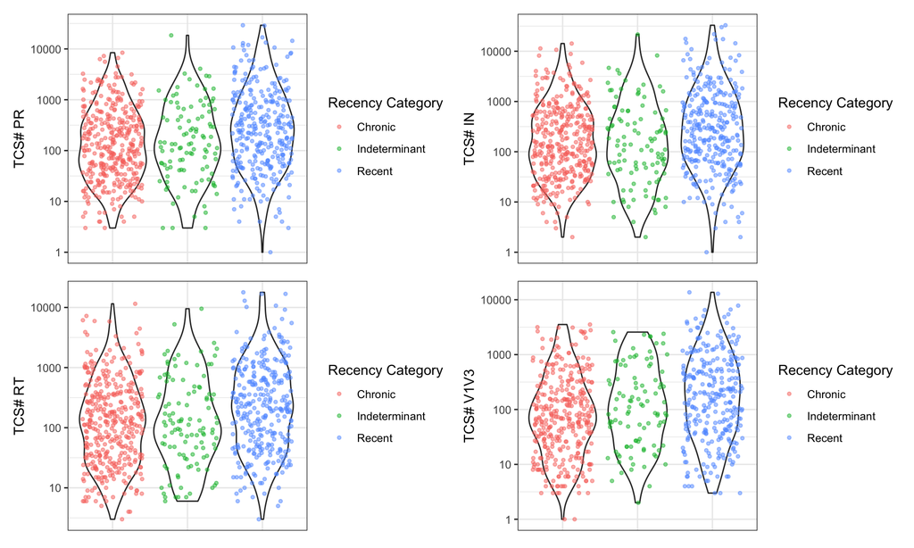

```r
df_tcs <- dfall %>% select(c(
                             "recent_cat",
                             "TCS_RT",
                             "TCS_PR",
                             "TCS_IN",
                             "TCS_V1V3"
                             )
)

tcs_chart <- function(cat, title) {
  df_tcs %>%
  ggplot(aes(x = recent_cat, y = cat)) +
  geom_violin() +
  geom_jitter(aes(colour = recent_cat), size = 1, alpha = 0.5) +
  scale_y_continuous(name = title, trans = 'log10') +
  labs(x = "Recency Category", color = "Recency Category") +
  theme_bw() +
    theme(axis.title.x=element_blank(),
        axis.text.x=element_blank(),
        axis.ticks.x=element_blank())
}

p1 <- tcs_chart(df_tcs$TCS_PR, "TCS# PR")
p2 <- tcs_chart(df_tcs$TCS_IN, "TCS# IN")
p3 <- tcs_chart(df_tcs$TCS_RT, "TCS# RT")
p4 <- tcs_chart(df_tcs$TCS_V1V3, "TCS# V1V3")

(p1 | p2) /
  (p3 | p4)
```

#### 3. Performing logistic regression and plot the values using `ggplot2` and `finalfit`.

```r
library(finalfit)
library(ggplot2)

dfall_logic <- dfall %>% filter(dx_ngs_cat=="<30 days" & recent_cat!="Indeterminant" ) %>%
                            mutate(Recenct_Infection = ifelse(recent_cat == "Recent", 1, 0),
                                   ngscollectyr = as.character(ngscollectyr),
                                   Age = ifelse(age_cat30 == "Yes", "≤30 y/o", ">30 y/o"),
                                   gender = ifelse(gender == "Male", "M", gender),
                                   gender = ifelse(gender == "Female", "F", gender),
                                   gender = ifelse(gender == "Transgender Female", "Trans. F", gender),
                                   gender = ifelse(gender == "Transgender Male", "Trans. M", gender),
                                   gender = relevel(as.factor(gender), ref = "M"))


names(dfall_logic)[names(dfall_logic) == "owning_jd_region_fsu"] <- "Region"
names(dfall_logic)[names(dfall_logic) == "ngscollectyr"] <- "Year"
names(dfall_logic)[names(dfall_logic) == "gender"] <- "Gender"
names(dfall_logic)[names(dfall_logic) == "racecat"] <- "Race"
names(dfall_logic)[names(dfall_logic) == "incluster"] <- "Cluster"

explanatory = c("Race", "Gender", "Age", "Year", "Region", "Cluster")
dependent = "Recenct_Infection"
dfall_logic %>%
  finalfit(dependent, explanatory, metrics=TRUE) -> t2
t2 %>% knitr::kable()
```

|  | Dependent: Recenct_Infection |  | unit | value | Coefficient (univariable) | Coefficient (multivariable) |
| --- | --- | --- | --- | --- | --- | --- |
| 12 | Race | White | Mean (sd) | 0.6 (0.5) | - | - |
| 9 |  | Black | Mean (sd) | 0.5 (0.5) | -0.09 (-0.19 to 0.01, p=0.080) | -0.13 (-0.23 to -0.02, p=0.016) |
| 10 |  | Hispanic | Mean (sd) | 0.3 (0.5) | -0.24 (-0.38 to -0.10, p=0.001) | -0.23 (-0.37 to -0.09, p=0.001) |
| 11 |  | Other/Unkn | Mean (sd) | 0.5 (0.5) | -0.10 (-0.27 to 0.08, p=0.272) | -0.12 (-0.29 to 0.06, p=0.192) |
| 6 | Gender | M | Mean (sd) | 0.5 (0.5) | - | - |
| 5 |  | F | Mean (sd) | 0.5 (0.5) | 0.03 (-0.08 to 0.14, p=0.580) | 0.11 (0.00 to 0.22, p=0.044) |
| 7 |  | Trans. F | Mean (sd) | 0.3 (0.5) | -0.17 (-0.44 to 0.09, p=0.200) | -0.15 (-0.41 to 0.10, p=0.238) |
| 1 | Age | >30 y/o | Mean (sd) | 0.4 (0.5) | - | - |
| 2 |  | ≤30 y/o | Mean (sd) | 0.5 (0.5) | 0.12 (0.05 to 0.20, p=0.002) | 0.11 (0.03 to 0.19, p=0.005) |
| 20 | Year | 2018 | Mean (sd) | 0.4 (0.5) | - | - |
| 21 |  | 2019 | Mean (sd) | 0.5 (0.5) | 0.08 (-0.02 to 0.17, p=0.113) | 0.07 (-0.02 to 0.16, p=0.128) |
| 22 |  | 2020 | Mean (sd) | 0.6 (0.5) | 0.13 (0.01 to 0.25, p=0.030) | 0.11 (-0.01 to 0.23, p=0.062) |
| 23 |  | 2021 | Mean (sd) | 0.4 (0.5) | -0.01 (-0.11 to 0.09, p=0.817) | 0.02 (-0.08 to 0.12, p=0.734) |
| 13 | Region in NC | Asheville | Mean (sd) | 0.3 (0.5) | - | - |
| 14 |  | Charlotte | Mean (sd) | 0.5 (0.5) | 0.11 (-0.07 to 0.29, p=0.229) | 0.15 (-0.03 to 0.33, p=0.106) |
| 15 |  | Fayetteville | Mean (sd) | 0.5 (0.5) | 0.14 (-0.03 to 0.31, p=0.109) | 0.13 (-0.04 to 0.30, p=0.129) |
| 16 |  | Greensboro | Mean (sd) | 0.4 (0.5) | 0.09 (-0.06 to 0.23, p=0.232) | 0.08 (-0.06 to 0.23, p=0.269) |
| 17 |  | Raleigh | Mean (sd) | 0.5 (0.5) | 0.18 (0.03 to 0.32, p=0.021) | 0.19 (0.04 to 0.34, p=0.013) |
| 18 |  | Wilmington | Mean (sd) | 0.5 (0.5) | 0.15 (-0.06 to 0.36, p=0.154) | 0.12 (-0.08 to 0.32, p=0.251) |
| 19 |  | Winterville | Mean (sd) | 0.4 (0.5) | 0.08 (-0.08 to 0.23, p=0.332) | 0.07 (-0.08 to 0.23, p=0.351) |
| 3 | In Clusters | No | Mean (sd) | 0.3 (0.5) | - | - |
| 4 |  | Yes | Mean (sd) | 0.5 (0.5) | 0.24 (0.16 to 0.32, p<0.001) | 0.21 (0.14 to 0.29, p<0.001) |
| 8 | NA | NA | NA | NA | -0.46 (-1.44 to 0.52, p=0.358) | -0.59 (-1.54 to 0.36, p=0.226) |

| Number in dataframe = 702, Number in model = 702, Missing = 0, Log-likelihood = -470.93, AIC = 979.9, R-squared = 0.098, Adjusted R-squared = 0.076 |
| --- |

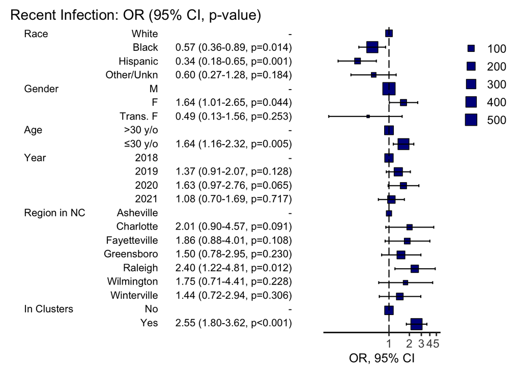

```r
dfall_logic %>%
  or_plot(dependent, explanatory,
          table_text_size=3.5,
          title_text_size=14,
          dependent_label = "Recent Infection",
          #breaks = c(0.1,0.5,1,2,3,4,5,6),
          column_space = c(-0.5, 0, 0.5),
          plot_opts=list(xlab("OR, 95% CI"),
                         theme(axis.title = element_text(size=12),
                               legend.position = "right",
                               legend.title = element_blank(),
                               legend.justification = c("right", "top")
                               ))) # + guide_legend(title="my awesome title")
```

#### 4. Making beautiful phylogenetic trees.

Example Tree 1

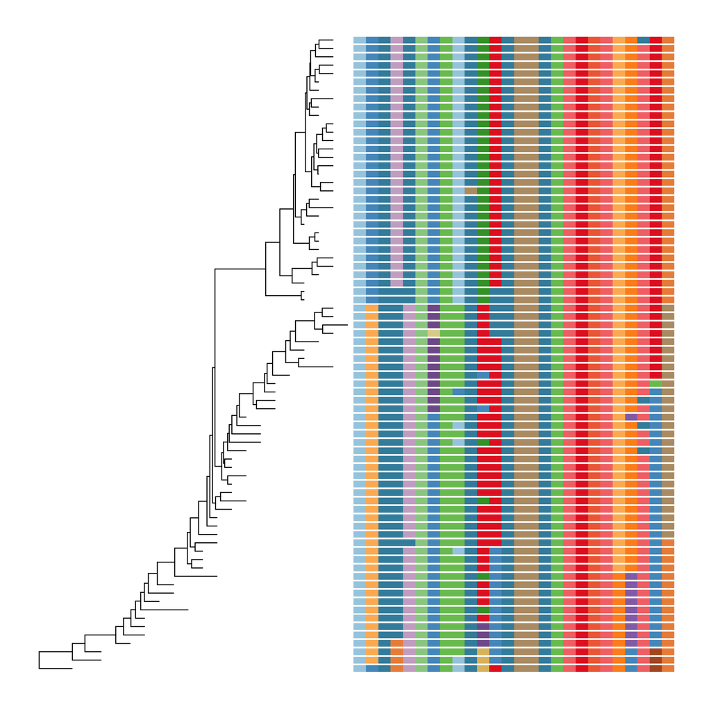

Example Tree 2

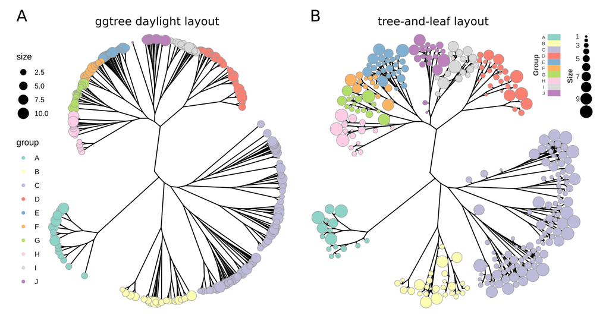